# Improving Manhattan’s street tree population

Tyler Garner

29 December 2022

## Table of contents

- 1 - Introduction
- 2 - Methodology
  - 2.1 - Data
    - 2.1.1 - Tree census variables
    - 2.1.2 - Neighborhood variables
  - 2.2 - Analyses
- 3 - Results
  - 3.1 - Exploratory Data Analysis (EDA)
    - 3.1.1 - Number of trees by species
    - 3.1.2 - Trunk sizes
    - 3.1.3 - Tree problems
  - 3.2 - The most common tree species in Manhattan
  - 3.3 - Neighborhoods with the most trees
  - 3.4 - Visualizing Manhattan’s neighborhoods and tree locations
  - 3.5 - Recommendations for future tree planting
- 4 - Conclusions

# 1 - Introduction

The design of urban environments can affect sense of safety, increase public engagement, and provide inspiration, which makes it a critical factor in a city’s social life and economy. An important part of urban design is the inclusion of tree life to create a greener and more attractive habitat that can facilitate air pollution cleaning, provide shade, and encourage the use of public spaces. Therefore, identifying tree species with desirable characteristics for metropolitan spaces is essential for urban design teams to best create a thriving, welcoming atmosphere.

Two critical factors to consider when choosing a tree species for planting are the overall quality of health of that species in an urban environment and the specie’s size. Trees in poor health are unattractive which may reverse the benefits offered by a green environment. Larger trees tend to have canopies that provide shade to a wider area and higher up branches that are less likely to block paths. Other factors to consider are tree diversity, maintenance costs, and the invasiveness of species that may pose a threat to other plant life in the area.

The goal of this analysis is to deliver insights on the current street trees around Manhattan and provide recommendations for future tree planting. Street tree census and neighborhood geospatial data sets from [NYC Open Data](https://opendata.cityofnewyork.us/data/) were employed to determine the non-invasive tree species with the most desirable characteristics as defined by overall tree health and size. The insights gathered through this analysis can be used by urban design teams to select the best trees for future planting in Manhattan’s neighborhoods.

This report covers the following:

1. Identifying the most common tree species in Manhattan.
2. Distinguishing neighborhoods with the most trees.
3. A visualization of Manhattan’s neighborhoods and tree locations.
4. Recommendations on the 10 best tree species for future planting.

# 2 - Methodology

## 2.1 - Data

Two data sets are provided for this analysis. The first contains street tree census data for the Manhattan area while the second has general neighborhood geographical information across the NYC boroughs. The variables in these data sets are detailed in the following two subsections.

### 2.1.1 - Tree census variables

- **tree_id** - Unique id of each tree.
- **tree_dbh** - The diameter of the tree in inches measured at 54 inches above the ground.
- **curb_loc** - Location of the tree bed in relation to the curb. Either along the curb or offset from the curb.
- **spc_common** - Common name for the species.
- **status** - Indicates whether the tree is alive or standing dead.
- **health** - Indication of the tree’s health (Good, Fair, and Poor).
- **root_stone** - Indicates the presence of a root problem caused by paving stones in the tree bed.
- **root_grate** - Indicates the presence of a root problem caused by metal grates in the tree bed.
- **root_other** - Indicates the presence of other root problems.
- **trunk_wire** - Indicates the presence of a trunk problem caused by wires or rope wrapped around the trunk.
- **trnk_light** - Indicates the presence of a trunk problem caused by lighting installed on the tree.
- **trnk_other** - Indicates the presence of other trunk problems.
- **brch_light** - Indicates the presence of a branch problem caused by lights or wires in the branches.
- **brch_shoe** - Indicates the presence of a branch problem caused by shoes in the branches.
- **brch_other** - Indicates the presence of other branch problems.
- **postcode** - Five-digit zip code where the tree is located.x
- **nta** - Neighborhood Tabulation Area (NTA) code from the 2010 US Census for the tree.
- **nta_name** - Neighborhood name.
- **latitude** - Latitude of the tree, in decimal degrees.
- **longitude** - Longitude of the tree, in decimal degrees.

### 2.1.2 - Neighborhood variables

- **borocode** - Code number for the borough.
- **boroname** - Name of the borough.
- **countyfips** - Federal Information Processing System (FIPS) codes for the county.
- **shape_area** - Area of the neighborhood in square feet.
- **shape_leng** - Maximum length of the neighborhood in feet.
- **ntacode** - NTA code (matches Tree Census information).
- **ntaname** - Neighborhood name (matches Tree Census information).
- **geometry** - Polygon that defines the neighborhood.

## 2.2 - Analyses

1. What are the most common tree species in Manhattan?

This question was approached in two ways. First, the total number of trees for each unique common species was calculated and ordered by species with the highest population in Manhattan. In the second approach the text from the common species names was extracted to create more generalized groupings of tree species, then the number of trees within each group was similarly counted and ordered.

2. Which are the neighborhoods with the most trees?

This question was also approached in two ways. First, the total number of trees within each neighborhood was counted and ordered by neighborhoods with the highest population of trees. Second, the total number of trees per square foot was calculated for each neighborhood, then the neighborhoods were similarly ordered by highest tree density.

3. A visualization of Manhattan’s neighborhoods and tree locations.

To visualize Manhattan’s neighborhoods and their trees in one figure, each tree was plotted as a point on a map of Manhattan and given a color based on which neighborhood the tree resided in. Then, an outline for each neighborhood was drawn to clearly define their borders. A legend is supplied to differentiate which colors represent each neighborhood. A supplemental figure was also generated to better visualize the tree density of each neighborhood.

4. What ten tree species would you recommend the city plant in the future?

This analysis focused only on adult trees (at least 5 inches in diameter). The proportion of adult trees in good or poor health and quantile statistics on their sizes were calculated for each species. Species identified as invasive species by the United States Geological Survey or species with too few observations were filtered out. A weighted ranking approach was employed to order the tree species by those with the best overall health quality and size. Finally, qualitative research on the top ranked species was performed to select the 10 species with the best characteristics for future planting in Manhattan.

# 3 - Results

## 3.1 - Exploratory Data Analysis (EDA)

This section covers data quality control, cleaning, and exploration. The following libraries are used for this analysis:

- `sf` - Tools for geospatial analysis and visualization.
- `tidytext` - Tools for text analysis.
- `pals` - Provides additional and larger color palettes for visualizations.
- `htmlTable` - Build web-friendly tables.
- `gridExtra` - Functions for arranging graphics on a grid.
- `ggrepel` - Graphics functions to prevent text overlap when labeling.
- `tidyverse` - Suite of tools for data manipulation and visualization.

After loading the libraries and the tree census data set we will print basic information about the data, including its dimensions and some descriptive statistics of the variables.

```r
libs <- c('sf', 'tidytext', 'pals', 'htmlTable', 'gridExtra', 'ggrepel', 'tidyverse')

sapply(libs, library, character.only = TRUE)

trees <- read_csv('../data/raw/trees.csv',
                  show_col_types = FALSE)

dim(trees)
summary(trees)
```

[output not shown]

The data set contains 64,229 observations across 21 columns, most of which are of the `character` class and may instead be more useful as the `factor` type. The maximum and minimum values for tree diameter (**tree_dbh**) appear to be very high and low, respectively, so we should check for potential outliers. The latitude and longitude values appear to spread over a small area and do not have any obvious issues.

For the `character` variables, we will determine how many unique values are in each to assess whether we want to keep them as the `character` class or convert them to the `factor` type.

```r
trees %>%
  select(where(is_character)) %>%
  apply(2, function(x) length(unique(x)))
```

```
##   curb_loc spc_common     status     health root_stone root_grate root_other
##          2        129          2          4          2          2          2
## trunk_wire trnk_light trnk_other brch_light  brch_shoe brch_other        nta
##          2          2          2          2          2          2         28
##   nta_name
##         28
```

The number of unique values for each of the `character` columns ranges between 2 and 129, with most variables at or near 2. Since we have a large amount of observations we can assign each as the `factor` type which will be useful for grouping observations by their features. We will then print new summary statistics for the data set.

```r
trees <- trees %>%
  mutate(across(where(is_character), factor))

summary(trees)
```

```
##       ...1          tree_id          tree_dbh                 curb_loc
##  Min.   :    1   Min.   :   356   Min.   :  0.000   OffsetFromCurb: 4297
##  1st Qu.:16058   1st Qu.: 97879   1st Qu.:  4.000   OnCurb        :59932
##  Median :32115   Median :189975   Median :  8.000
##  Mean   :32115   Mean   :206631   Mean   :  8.631
##  3rd Qu.:48172   3rd Qu.:286769   3rd Qu.: 11.000
##  Max.   :64229   Max.   :722674   Max.   :318.000
##
##         spc_common      status       health      root_stone  root_grate
##  honeylocust :13176   Alive:62427   Fair:11460   No :51653   No :61747
##  Callery pear: 7297   Dead : 1802   Good:47358   Yes:12576   Yes: 2482
##  ginkgo      : 5859                 Poor: 3609
##  pin oak     : 4584                 NA's: 1802
##  Sophora     : 4453
##  (Other)     :27059
##  NA's        : 1801
##  root_other  trunk_wire  trnk_light  trnk_other  brch_light  brch_shoe
##  No :59212   No :63312   No :63898   No :58649   No :63354   No :64168
##  Yes: 5017   Yes:  917   Yes:  331   Yes: 5580   Yes:  875   Yes:   61
##
##
##
##
##
##  brch_other     postcode          nta
##  No :57665   Min.   :   83   MN12   : 5807
##  Yes: 6564   1st Qu.:10014   MN40   : 4616
##              Median :10025   MN23   : 3801
##              Mean   : 9886   MN03   : 3469
##              3rd Qu.:10032   MN13   : 2931
##              Max.   :10282   MN36   : 2924
##                              (Other):40681
##                                        nta_name        latitude
##  Upper West Side                           : 5807   Min.   :40.70
##  Upper East Side-Carnegie Hill             : 4616   1st Qu.:40.75
##  West Village                              : 3801   Median :40.78
##  Central Harlem North-Polo Grounds         : 3469   Mean   :40.78
##  Hudson Yards-Chelsea-Flatiron-Union Square: 2931   3rd Qu.:40.81
##  Washington Heights South                  : 2924   Max.   :40.87
##  (Other)                                   :40681
##    longitude
##  Min.   :-74.02
##  1st Qu.:-73.99
##  Median :-73.97
##  Mean   :-73.97
##  3rd Qu.:-73.95
##  Max.   :-73.91
##
```

The summary statistics now report missing values, specifically in the **spc_common** and **health** columns. The total number of missing values in both variables is about the same, so we will check how many observations are missing values for both variables. Also to note, the number of missing values also matches the ‘Dead’ value for the **status** variable, so we will check how many observations have missing values in both variables.

```r
sum(is.na(trees$spc_common) & is.na(trees$health))
```

```
## [1] 1801
```

```r
sum(is.na(trees$health) & trees$status == 'Dead')
```

```
## [1] 1802
```

All observations except one with missing values in the **health** variable also have a missing value in the **spc_common** variable. Additionally, all of the missing values in the **health** variable come from observations where **health** has a value of ‘Dead’. Therefore, instead of dropping observations we will recode the missing values in **spc_common** as ‘Unknown’ and those in **health** as ‘Dead’.

```r
trees <- trees %>%
  mutate(spc_common = fct_explicit_na(spc_common, 'Unknown'),
         health = fct_explicit_na(health, 'Dead'))
```

### 3.1.1 - Number of trees by species

As shown previously, there are 129 unique values for the common species names,**spc_common** (including the formerly missing values now labeled as ‘Unknown’). We will filter out dead trees whose species we do not know, then create a histogram and rug plot to visualize how the total observations for each common species name are distributed.

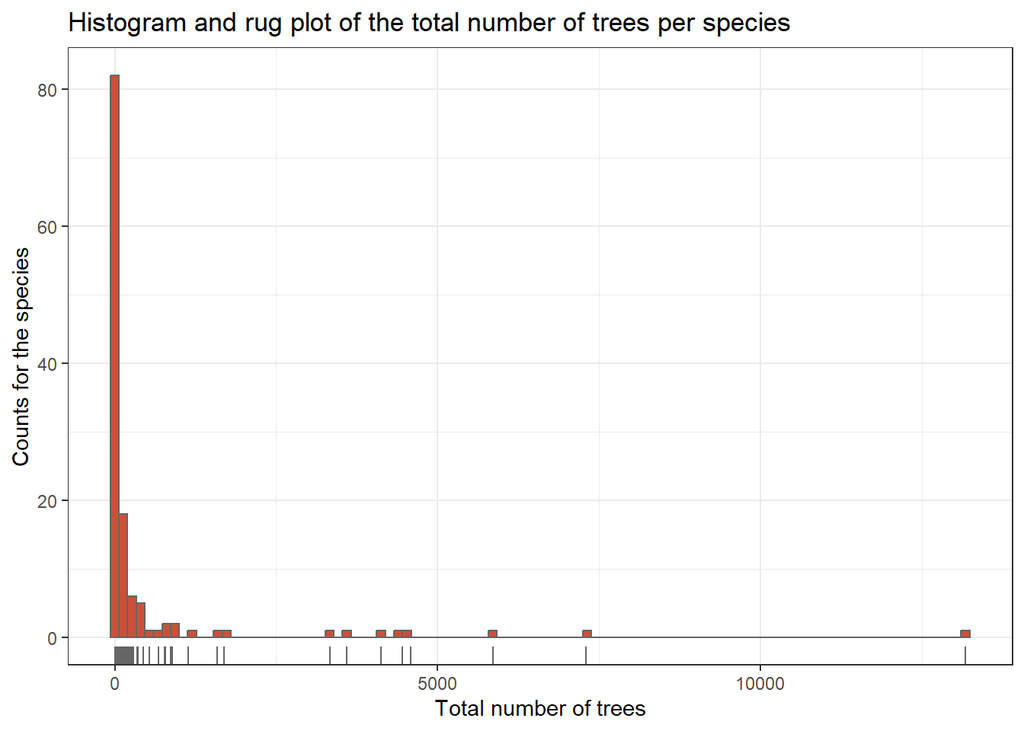

```r
trees %>%
  count(spc_common) %>%
  filter(spc_common != 'Unknown') %>%
  ggplot(aes(x = n)) +
    geom_histogram(bins = 100, fill = 'tomato3', color = 'grey40') +
    geom_rug(color = 'grey40') +
    labs(x = 'Total number of trees',
         y = 'Counts for the species',
         title = 'Histogram and rug plot of the total number of trees per species') +
    theme_bw()
```

In the plot we can see that most of the species are uncommon around Manhattan while a small subset of species make up the majority of all trees. Specifically, there are 8 species with a population of at least 2,500 in Manhattan which represent 72.3% of the total tree population.

### 3.1.2 - Trunk sizes

Next, we will similarly create a histogram and rug plot to observe the distribution of tree trunk diameters for the living trees.

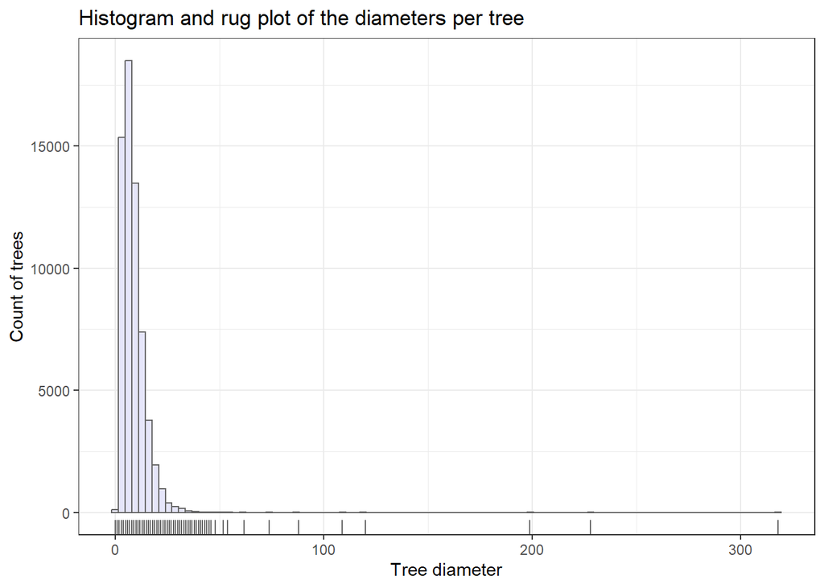

```r
trees %>%
  filter(status == 'Alive') %>%
    ggplot(aes(x = tree_dbh)) +
    geom_histogram(bins = 100, fill = 'lavender', color = 'grey40') +
    geom_rug(color = 'grey40') +
    labs(x = 'Tree diameter',
         y = 'Count of trees',
         title = 'Histogram and rug plot of the diameters per tree') +
    theme_bw()
```

The distribution of trunk diameters is right-skewed with some extreme values. The right-skewness might be expected when measuring the size of plants that generally have grown for a long period of time. Some of the extreme values could alternatively be the result of entry error.

There are 43 tree diameter measurements that are recorded as 0. This could also be the result of data entry error or that these trees were not over 54 inches tall, which is the standard height where tree diameters are measured called the diameter at breast height (DBH). These points are few and less extreme so are unlikely to highly leverage our analyses so they will be left alone.

For the right-skew and extreme points, we will aim to keep the tailing while removing likely outliers that could have too much influence in later analyses. It appears that at around 50 inches the tailing ends and is followed by more isolated values. So, we will choose 50 inches as a cut-off point and replace the values above that threshold with their respective species median diameter.

```r
# Get the median diameter for each tree species
diam_med <- trees %>%
  group_by(spc_common) %>%
  summarize(median = median(tree_dbh))

# Replace outliers with their respective species median diameter
trees <- trees %>%
  mutate(tree_dbh = ifelse(tree_dbh > 50,
                           diam_med$median[which(diam_med$spc_common %in% spc_common)],
                           tree_dbh))
```

### 3.1.3 - Tree problems

The data set consists of 9 variables that indicate whether some type of issue is present for each tree, which can be generally categorized as either a root, trunk, or branch problem. We can plot the total proportion of trees experiencing each problem to determine if any issues are more common than others.

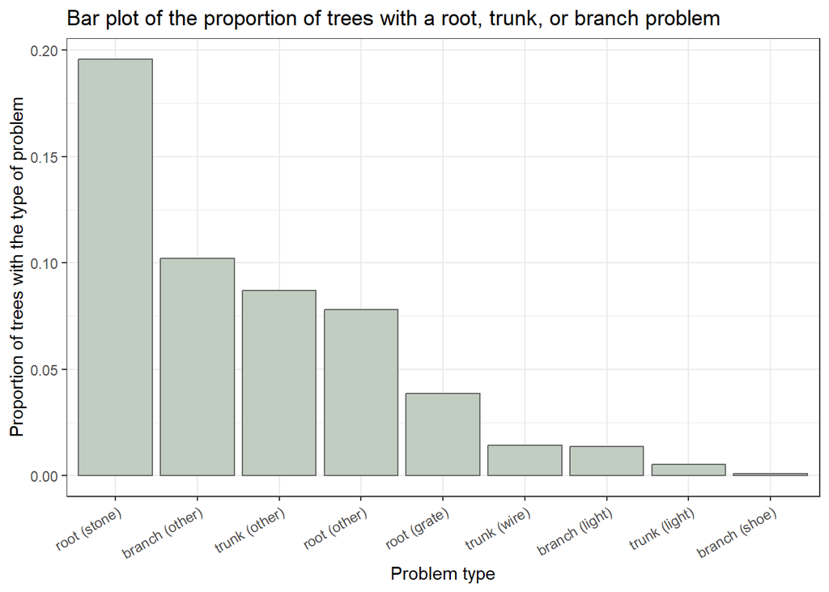

```r
# Subset and lengthen a new df with diameters, health, and root problems for further analysis
trees_probs <- trees %>%
  select(tree_dbh, health, root_stone:brch_other) %>%
  pivot_longer(root_stone:brch_other,
               names_to = 'Problem',
               values_to = 'Present') %>%
  mutate(Problem = paste0(str_replace_all(Problem, c('_' = ' (',
                                                     'trnk' = 'trunk',
                                                     'brch' = 'branch')),
                          ')'))

# Create a standard theme to use when the x-axis tick labels are long
theme_long_labs <- theme_bw() +
    theme(axis.text.x = element_text(angle = 30,
                                     vjust = 1,
                                     hjust = 1))

# Plot the proportion of trees with each problem
trees_probs %>%
  group_by(Problem) %>%
  summarize(prop_yes = sum(Present == 'Yes') / n()) %>%
  mutate(Problem = fct_reorder(factor(Problem), desc(prop_yes))) %>%
  ggplot(aes(x = Problem, y = prop_yes)) +
    geom_col(fill = 'honeydew3', color = 'grey40') +
    labs(x = 'Problem type',
         y = 'Proportion of trees with the type of problem',
         title = 'Bar plot of the proportion of trees with a root, trunk, or branch problem') +
    theme_long_labs
```

The bar chart above shows that problems caused by paving stones in the tree bed is the most common issue and double that of the next most common issue, the presence of other branch problems. Additionally, the other two root-based problems have a relatively high number of incidents to overall suggest that issues with tree roots are the most prevalent issues among those recorded. Finally, the proportion of branch issues caused by shoes in the branches is very low and could be worth grouping into the ‘branch (other)’ category.

Another insight to gather is how tree sizes are distributed depending on whether a problem exists. We can observe this by overlaying plots of the smoothed density estimates of their distributions.

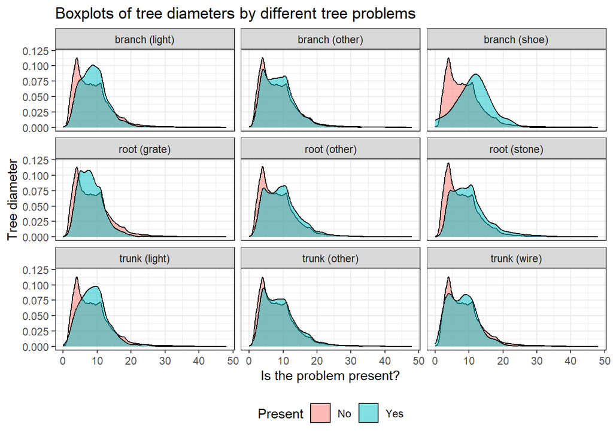

```r
# Create density plots of tree diameters by each of the 9 tree problems
trees_probs %>%
  select(tree_dbh, Problem, Present) %>%
  ggplot(aes(fill = Present, x = tree_dbh)) +
    geom_density(alpha = 0.5) +
    facet_wrap(~ Problem) +
    labs(x = 'Is the problem present?',
         y = 'Tree diameter',
         title = 'Boxplots of tree diameters by different tree problems') +
    theme_bw() +
    theme(legend.position = 'bottom')
```

In the density plots above, we can note a general trend for a problem being present in larger sized trees. The most notable of these is the presence of shoes in the branches of larger trees, as the distribution, or shape, of diameters for trees with shoes in their branches is shifted right compared to those without shoes. This is similar for lights affecting either branches or trunks and for the presence of a metal grate in the tree bed. The other categories may also follow this trend, but to lesser degrees. Together, these observations suggest that the recorded problems tend to occur with older, larger trees.

Next, we will look at whether tree health is affected by any of these problems. For each type of problem, we will calculate the proportion of trees in each health category that is experiencing that issue and plot them.

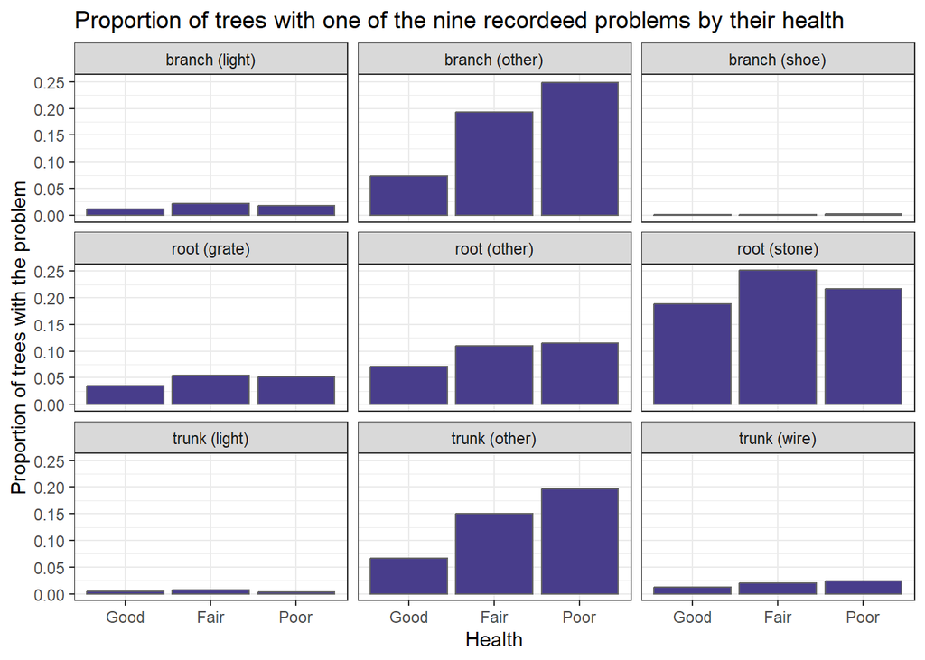

```r
# Create bar plots of the total proportion of problems by each type of health.
trees_probs %>%
  select(health, Problem, Present) %>%
  group_by(health, Problem) %>%
  summarize(prop_yes = sum(Present == 'Yes') / n()) %>%
  mutate(health = factor(health, levels = c('Good', 'Fair', 'Poor'))) %>%
  drop_na() %>%
  ggplot(aes(x = health, y = prop_yes)) +
    geom_col(fill = 'darkslateblue', color = 'grey40') +
    facet_wrap(~ Problem) +
    labs(x = "Health",
         y = "Proportion of trees with the problem",
         title = "Proportion of trees with one of the nine recordeed problems by their health") +
    theme_bw()
```

The bar charts indicate that, generally, the proportion of trees with issues increases from ‘Good’ to ‘Fair’ then ‘Poor’ health. A notable exception is the ‘root (stone)’ category where trees classified as being ‘fair’ in health have the highest proportion of reported issues, which could suggest that while paving stones in the tree beds are a common issue they do not affect tree health compared to the other recorded problems.

We should also observe whether the proportion of problems varies by species. For this, we will group all of the problems together in a new variable that indicates whether at least one of any root, trunk, or branch problem exists, then measure and plot the proportion of trees with at least one issue by species.

There are many trees with very low populations which could inflate or deflate their estimated proportions of issues. Therefore, a cut-off value will be selected to remove species that have a population lower than that chosen value. It will be assumed that the current tree data set is a sample from a larger population of interest, which gives the sample size needed for estimating the proportion as:

$$n = \frac{\hat{p} * (1 - \hat{p}) *
z_{\alpha/2}^2}{d^2}$$

where $n$ is the sample size, $\hat{p}$ is the estimated proportion of trees with issues, $d$ is the margin of error, and $z_{\alpha/2}$ is the z-value. We will choose to estimate $\hat{p}$ as the median proportion of trees with some issue, $d$ as a 10% margin of error, and $z_{\alpha/2}$ as the z-value at 95% confidence. We will then plot the species with the most and with the least issues.

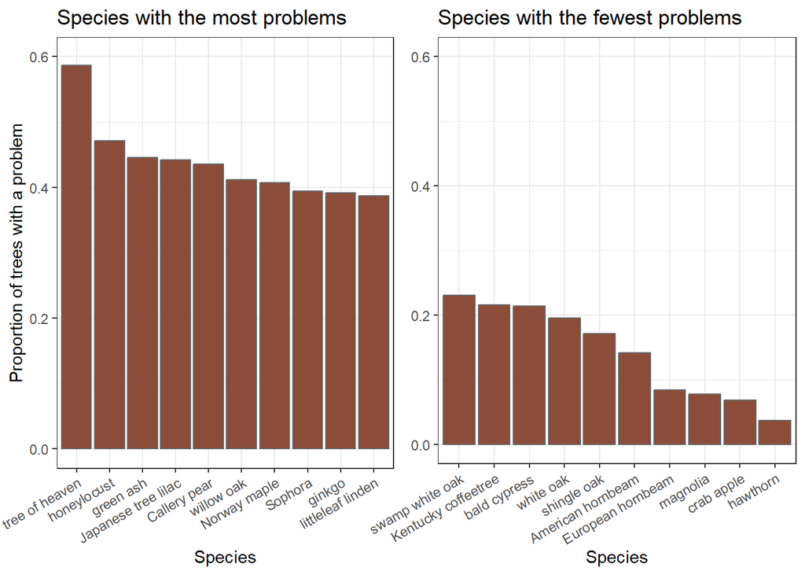

```r
# Create a new columns that identifies the trees with any problem
tree_test <- trees %>%
  select(root_stone:brch_other)
tree_test$sums <- rowSums(tree_test == 'Yes')
trees$any_prob <- ifelse(tree_test$sums == 0, 'No', 'Yes')

# Select then plot the trees with the highest proportion of problems
trees_top_probs <- trees %>%
  group_by(spc_common) %>%
  summarize(prop_yes = sum(any_prob == 'Yes') / n(),
            tot = n()) %>%
  filter(spc_common != 'Unknown') %>%
  arrange(desc(prop_yes))

# Calculate the median proportion of trees experiencing some type of problem by species
probs_med <- median(trees_top_probs$prop_yes)

# From the median proportion of trees in 'Good' health, estimate the smallest sample size using
# a margin of error = 10% and 95% confidence (z-value = 1.96)
z_val <- 1.96
error_margin <- 0.10
probs_min_n <- round((probs_med * (1 - probs_med) * z_val ** 2) / (error_margin ** 2), 0)

# Filter out species that have sample sizes lower than the estimated minimum n above
trees_top_probs <- trees_top_probs %>%
  filter(tot >= probs_min_n)

# Bar plot of the species with the highest number of problems
top_prop_plot <- trees_top_probs %>%
  head(n = 10) %>%
  mutate(spc_common = fct_reorder(spc_common, desc(prop_yes))) %>%
  ggplot(aes(x = spc_common,
             y = prop_yes)) +
    geom_col(fill = 'salmon4', color = 'grey40') +
    labs(x = 'Species',
         y = 'Proportion of trees with a problem',
         title = 'Species with the most problems') +
    scale_y_continuous(limits = c(0, 0.6)) +
    theme_long_labs

bot_prop_plot <- trees_top_probs %>%
  tail(n = 10) %>%
  mutate(spc_common = fct_reorder(spc_common, desc(prop_yes))) %>%
  ggplot(aes(x = spc_common,
             y = prop_yes)) +
    geom_col(fill = 'salmon4', color = 'grey40') +
    labs(x = 'Species',
         y = NULL,
         title = 'Species with the fewest problems') +
    scale_y_continuous(limits = c(0, 0.6)) +
    theme_long_labs

grid.arrange(top_prop_plot, bot_prop_plot,
             nrow = 1)
```

The bar charts above show the species with the highest (left) and the lowest (right) proportion of root, trunk, or branch problems. Species which tend to have more problems may be less suitable for future planting compared to species with fewer problems that are otherwise of similar health and size.

## 3.2 - The most common tree species in Manhattan

To determine which tree species are the most common in Manhattan, two approaches will be employed. First, the total number of trees associated with each unique common species name will be counted and ordered. Second, trees will be grouped based on shared words in their common names and the total number of trees with be counted in each group then ordered. For example, many of the species in this data set belong to the *Pinus* sub-genus and include the word ‘pine’ in their common name, such as ‘black pine’, ‘Virginia pine’, and ‘white pine’. So, each tree with a common name that includes ‘pine’ will be counted together in the ‘pine’ group and then counted separately for the ‘black’, ‘Virginia’, and ‘white’ groups.

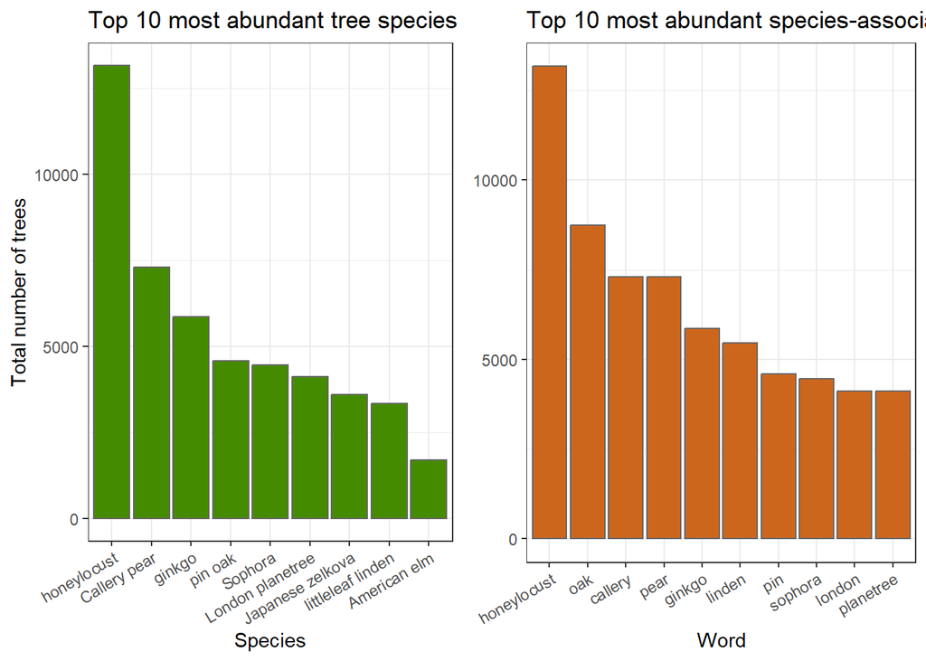

```r
# Count top 10 most abundant tree species and create bar chart objects
species_10 <- trees %>%
  group_by(spc_common) %>%
  count(name = 'total_trees') %>%
  arrange(desc(total_trees)) %>%
  head(n = 10) %>%
  ungroup() %>%
  drop_na() %>%
  filter(spc_common != 'Unknown')

sp1 <- species_10 %>%
  mutate(spc_common = fct_reorder(spc_common, desc(total_trees))) %>%
  ggplot(aes(x = spc_common,
             y = total_trees)) +
  geom_col() +
    geom_col(fill = 'chartreuse4',
             color = 'grey40') +
    scale_x_discrete(labels = function(x) str_wrap(x,
                                                   width = 20,
                                                   whitespace_only = FALSE)) +
    labs(x = 'Species',
         y = 'Total number of trees',
         title = 'Top 10 most abundant tree species') +
    theme_bw() +
    theme(axis.text.x = element_text(angle = 30,
                                     vjust = 1,
                                     hjust = 1))

# Create word tokens then count number of trees associated with each token and create plot object
spc_tokens <- trees %>%
  select(tree_id, spc_common) %>%
  mutate(spc_common = as.character(spc_common)) %>%
  unnest_tokens(word, spc_common) %>%
  mutate(word = tolower(word)) %>%
  distinct() %>%
  drop_na() %>%
  filter(word != 'Unknown')

scp_top <- spc_tokens %>%
  group_by(word) %>%
  summarize(n = n()) %>%
  arrange(desc(n)) %>%
  head(n = 10)

sp2 <- scp_top %>%
  mutate(word = fct_reorder(word, desc(n))) %>%
  ggplot(aes(x = word,
           y = n)) +
  geom_col() +
    geom_col(fill = 'chocolate3',
             color = 'grey40') +
    scale_x_discrete(labels = function(x) str_wrap(x,
                                                   width = 20,
                                                   whitespace_only = FALSE)) +
    labs(x = 'Word',
         y = NULL,
         title = 'Top 10 most abundant species-associated words') +
    theme_bw() +
    theme(axis.text.x = element_text(angle = 30,
                                     vjust = 1,
                                     hjust = 1))

# Plot both bar charts side-by-side
grid.arrange(sp1, sp2, nrow = 1)
```

Comparing the two bar charts we can conclude:

1. ‘honeylocust’ has the highest population in Manhattan with 13,176 trees.
2. ‘oak’ is the second most common species, with ‘pin oak’ being the most abundant type of oak tree.
3. ‘Callery pear’ is the third most common species and is the only type of pear tree.
4. The next most common tree species are ‘ginkgo’, ‘linden’ with ‘littleleaf linden’ as the most prominent, ‘Sophora’, and ‘London planetree’.

## 3.3 - Neighborhoods with the most trees

The geospatial data set provided by DataCamp is corrupted and will not load properly, either locally or in the DataCamp work space. Therefore, we will load the raw data directly from NYC Open Data then select only the eight intended variables. A new object called `manhattan` will be created to include data only from the Manhattan borough.

```r
neighborhoods <- st_read('../data/raw/direct_NYC/geo_export_be6f9d73-0dae-46ea-bbed-99ae04ed44e2.shp',
                         quiet=TRUE) %>%
  select(borocode, boroname, countyfips, ntacode, ntaname, shape_area, shape_leng, geometry)

manhattan <- neighborhoods %>%
  filter(boroname == 'Manhattan')
```

Next, we will determine which neighborhoods have the highest tree population. Then, we will use the geospatial data to calculate the number of trees per square mile. The top 5 neighborhoods in both categories will be plotted side-by-side for comparisons.

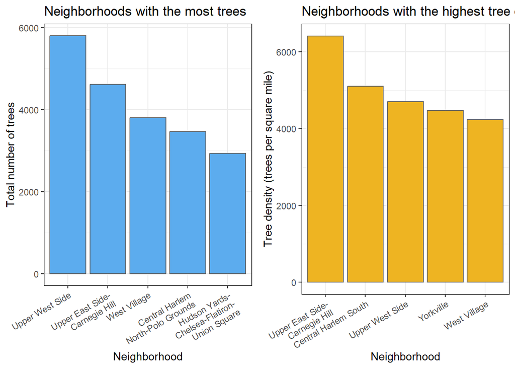

```r
# Create a ggplot object for the top 10 neighborhoods with the most trees
top_total <- trees %>%
  group_by(nta_name) %>%
  summarize(total_trees = n()) %>%
  arrange(desc(total_trees)) %>%
  head(n = 5)

p1 <- top_total %>%
  mutate(nta_name = fct_reorder(nta_name,
                                desc(total_trees))) %>%
    ggplot(aes(x = nta_name,
             y = total_trees)) +
    geom_col(fill = 'steelblue2',
             color = 'grey40') +
    scale_x_discrete(labels = function(x) str_wrap(x,
                                                   width = 20,
                                                   whitespace_only = FALSE)) +
    labs(x = 'Neighborhood',
         y = 'Total number of trees',
         title = 'Neighborhoods with the most trees') +
    theme_bw() +
    theme(axis.text.x = element_text(angle = 30,
                                     vjust = 1,
                                     hjust = 1))

# Calculate tree density in trees per square mile for each neighborhood then create plot object
# for top neighborhoods
tree_density <- trees %>%
  select(nta, nta_name) %>%
  left_join(manhattan %>% select(ntacode, shape_area),
            by = c('nta' = 'ntacode')) %>%
  group_by(nta_name) %>%
  summarize(tree_by_sq_ft = n() / max(shape_area)) %>%
  mutate(tree_by_sq_mile = tree_by_sq_ft / 3.58701e-8) %>%
  arrange(desc(tree_by_sq_mile))

top_5_density <- tree_density %>%
  head(n = 5)

p2 <- top_5_density %>%
  mutate(nta_name = fct_reorder(nta_name,
                                desc(tree_by_sq_mile))) %>%
  ggplot(aes(x = nta_name,
             y = tree_by_sq_mile)) +
    geom_col(fill = 'goldenrod2',
             color = 'grey40') +
    scale_x_discrete(labels = function(x) str_wrap(x,
                                                   width = 20,
                                                   whitespace_only = FALSE)) +
    labs(x = 'Neighborhood',
         y = 'Tree density (trees per square mile)',
         title = 'Neighborhoods with the highest tree density') +
    theme_bw() +
    theme(axis.text.x = element_text(angle = 30,
                                     vjust = 1,
                                     hjust = 1))

# Plot both graphs side-by-side
grid.arrange(p1, p2, nrow = 1)
```

From the bar charts above we can conclude:

1. The Upper West Side has the highest population of trees.
2. The Upper East Side-Carnegie Hall has the highest tree density.
3. The Upper West Side, Upper East Side-Carnegie Hall, and West Village all rank in the top 5 for highest tree population and number of trees per square mile.

## 3.4 - Visualizing Manhattan’s neighborhoods and tree locations

For this visualization we will plot the tree locations using a distinct color for the trees that reside in each neighborhood, then overlay the NTA neighborhood borders. We will also create a second visualization that displays the tree density for each neighborhood.

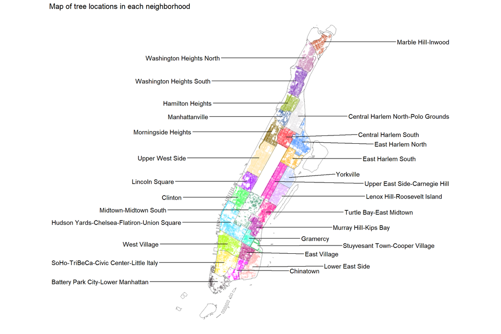

```r
# Get the centers for each neighborhood and assign their latitudes and longitudes
man_centers <- st_coordinates(st_centroid(manhattan$geometry))
manhattan$lon <- man_centers[, 1]
manhattan$lat <- man_centers[, 2]

# Set the 'etc' NTA name to NA so that it gets drawn but not labeled
manhattan <- manhattan %>%
  mutate(ntaname = ifelse(ntaname == 'park-cemetery-etc-Manhattan', NA, ntaname))

# Create a column with values to nudge based off of a linear formula to split Manhattan and
# account for the length of the neighborhood name when nudging the text
manhattan <- manhattan %>%
  mutate(to_nudge = ifelse(lat >= lon * 1.942 + 184.425,
                           -sqrt(nchar(ntaname))/45, sqrt(nchar(ntaname))/48))

# Plot all of the tree locations on a map of Manhattan and use different colors for each
# neighborhood
tree_loc_plot <- ggplot(manhattan) +
  geom_point(data = trees,
             aes(longitude, latitude, color = nta_name),
             size = 0.5, alpha = 0.05) +
  geom_sf(fill = NA) +
  scale_color_manual(values = as.vector(polychrome())) +
  geom_text_repel(aes(x = lon, y = lat, label = ntaname),
                  nudge_x = manhattan$to_nudge,
                  box.padding = 0.28,
                  na.rm = TRUE) +
  theme_void() +
  labs(title = 'Map of tree locations in each neighborhood') +
  theme(legend.position = 'none')

# Plot the density of trees by neighborhood on a similar map of Manhattan
tree_den_plot <- left_join(manhattan, tree_density,
          by = c('ntaname' = 'nta_name')) %>%
  ggplot() +
  geom_sf(aes(fill = tree_by_sq_mile)) +
  scale_fill_gradient(name = 'Trees per square mile',
                      low = 'lightgreen',
                      high = 'forestgreen',
                      na.value = 'white') +
  geom_text_repel(aes(x = lon, y = lat, label = ntaname),
                  nudge_x = manhattan$to_nudge,
                  box.padding = 0.28,
                  na.rm = TRUE) +
  theme_void() +
  labs(title = 'Map of tree densities for each neighborhood')

tree_loc_plot
```

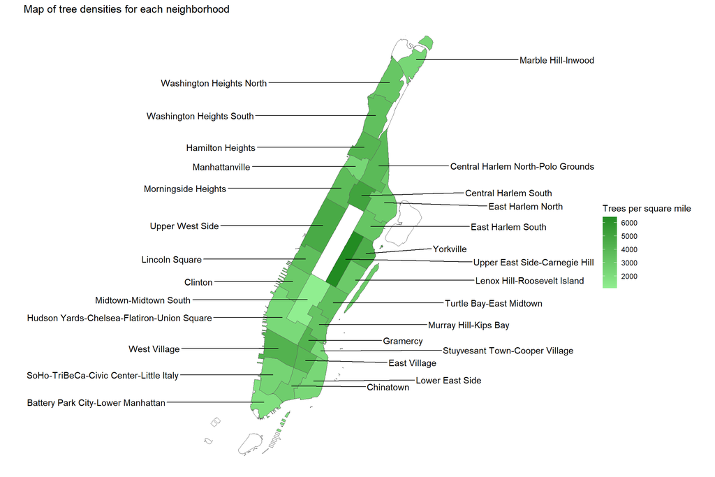

```r
tree_den_plot
```

In the plots above the unfilled regions are either parks, cemeteries, or other non-neighborhood features. Similar to the previous results, the Upper East Side-Carnegie Hall, Central Harlem South, and the Upper West Side each appear to be densely populated with trees compared to the other neighborhoods. Conversely, Midtown-Midtown South, Battery Park City-Lower Manhattan, and Stuyvesant Town-Copper Village are sparsely populated. The neighborhoods around Central Park appear to have high tree populations except for Midtown-Midtown South, which actually ranked the lowest for tree density.

## 3.5 - Recommendations for future tree planting

First, the data set will be filtered to only select adult trees (defined by a diameter of at least 5 inches, ([USDA Forest Service](https://www.fs.usda.gov/detail/r5/landmanagement/resourcemanagement/?cid=fsbdev3_048158)).) that are alive. Juvenile trees are removed because we are more interested in how adult trees fair in the Manhattan area. Dead trees are removed because we have no information on why they are dead, so we do not want to penalize species that have higher counts of dead trees due to external factors, such as cutting for construction, the same as species whose dead trees result from disease.

From the filtered data set, the percentage of adult trees categorized as either in ‘Good’ or ‘Poor’ health and the 25th quantile, 50th quantile (median), and 75th quantile for the diameters will be calculated for each species. The given common name will be kept and used for this analysis. Additionally, species with a population below a certain size will be removed under the assumption that there is not enough information for inclusion of those species in this analysis. The threshold will be chosen with the same equation and parameters as in section 3.1.3. Invasive species as identified in the [United States Register of Introduced and Invasive Species (US-RIIS) (ver. 2.0, November 2022)](https://www.sciencebase.gov/catalog/item/62d59ae5d34e87fffb2dda99?community=USGS+Science+Analytics+and+Synthesis+Foundational+Data) will also be removed from consideration.

Each species will be ranked on health and size using a weighted-ranking approach. We will assume that the desire for a tree in good health and with a large size are equal, so the features for health and diameter will be weighted equally (both contribute half to the final rankings).

For tree health, we will further weigh ‘Good’ health as accounting or 75% of the weight of the health ranking and ‘Poor’ health to 25%, while not including ‘Fair’. This weighing approach was chosen for a few reasons. Since dead trees were removed, all of the health quality information can be extracted by the proportion of trees in ‘Good’ and ‘Poor’ health as if a tree is not in either state it would be recorded as ‘Fair’ otherwise, which we can assume to be neutral. Additionally, there is a larger range in the proportion of trees in ‘Good’ health by species compared to ‘Poor’ health, and we are likely more interested in having a high proportion of trees in ‘Good’ health, so we add additional ranking weight for species that have a higher overall health quality.

The 25th, 50th (median), and 75th quantiles for adult tree diameters were selected and weighted as accounting for 25%, 50%, and 25% of the size ranking, respectively. The minimum value for diameter was not included since a cut-off of 5 was used, and therefore each adult tree would be expected to have the same minimum diameter. The maximum diameters were also not included because they represent a small proportion of old growth trees.

The weighted ranks were then ordered and the top 15 species were placed in a table with the health and diameter statistics on which they were weighed on and their total population.

```r
# Filter the data set to only include adult trees (>= 5 in. diameter) and remove dead trees
trees_adult <- trees %>%
  filter(status != 'Dead', tree_dbh >= 5)

# Create a df with statistics on tree health and size and filter out species with <50 pop
trees_health_diam <- trees_adult %>%
  group_by(spc_common) %>%
  summarize(perc_good = sum(health == 'Good') / n() * 100,
            perc_poor = sum(health == 'Poor') / n() * 100,
            diam_25 = as.numeric(quantile(tree_dbh, 0.25)),
            median_diam = median(tree_dbh),
            diam_75 = as.numeric(quantile(tree_dbh, 0.75)),
            total = n()) %>%
  arrange(desc(perc_good))

# Calculate the median proportion of trees in 'Good' health
good_med <- median(trees_health_diam$perc_good) / 100

# From the median proportion of trees in 'Good' health, estimate the smallest sample size using
# a margin of error = 10% and 95% confidence (z-value = 1.96)
z_val <- 1.96
error_margin <- 0.10
trees_min_n <- round((good_med * (1 - good_med) * z_val ** 2) / (error_margin ** 2), 0)

# Filter out species with populations lower than estimated above
trees_health_diam <- trees_health_diam %>%
  filter(total >= trees_min_n)

# Load the relevant data from the US invasive species register
invasive_df <- read_csv('../data/external/USRIISv2_MasterList.csv',
                        show_col_types = FALSE) %>%
  select(vernacularName) %>%
  # change to all lower-case and remove all spacing
  mutate(vernacularName = tolower(vernacularName),
         vernacularName_nospc = str_replace_all(vernacularName, '\\s', ''))

# Create a new df with values for all of the invasive species
invasive_species <- trees_health_diam %>%
  # change to all lower-case and remove all spacing
  mutate(spc_common = tolower(spc_common),
         spc_nospaces = str_replace_all(spc_common, '\\s', '')) %>%
  inner_join(invasive_df,
             by = c('spc_nospaces' = 'vernacularName_nospc')) %>%
  distinct()

# Remove the invasive species from the data set
trees_noninvasive <- trees_health_diam %>%
  filter(!tolower(spc_common) %in% invasive_species$spc_common)


# Print an HTML table of the top 15 trees using a weighted ranks-based approach
trees_noninvasive_top15 <- trees_noninvasive %>%
  mutate(good_rank = rank(1 / perc_good),
         poor_rank = rank(perc_poor),
         diam_25_rank = rank(1 / diam_25),
         median_rank = rank(1 / median_diam),
         diam_75_rank = rank(1 / diam_75)) %>%
  rowwise() %>%
  mutate(avg_rank = mean(c(good_rank * 0.75, poor_rank * 0.25,
                           diam_25_rank * 0.25, median_rank * 0.5,
                           diam_75_rank * 0.25))) %>%
  ungroup() %>%
  mutate(perc_good = round(perc_good, 1),
         perc_poor = round(perc_poor, 1),
         avg_rank = rank(avg_rank)) %>%
  arrange(avg_rank) %>%
  select(avg_rank, spc_common, perc_good, perc_poor,
         diam_25, median_diam, diam_75, total) %>%
  head(n = 15)

trees_noninvasive_top15 %>%
  addHtmlTableStyle(css.cell = 'padding-left: .25em; padding-right: .25em') %>%
  htmlTable(header = c('Weighted Rank', 'Species', '% Good', '% Poor', '25th Quantile', 'Median',
                       '75th Quantile', 'Population'),
            rnames = FALSE,
            cgroup = c('', 'Health', 'Diameter', ''),
            n.cgroup = c(2, 2, 3, 1))
```

| Weighted Rank | Species |  | Health % Good | Health % Poor |  | Diameter 25th Quantile | Diameter Median | Diameter 75th Quantile |  | Population |
| --- | --- | --- | --- | --- | --- | --- | --- | --- | --- | --- |
| 1 | willow oak |  | 87.3 | 1.5 |  | 8 | 11 | 15 |  | 716 |
| 2 | pin oak |  | 84.3 | 1.7 |  | 8 | 11 | 15 |  | 3455 |
| 3 | honeylocust |  | 83.7 | 1.2 |  | 8 | 10 | 12 |  | 11017 |
| 4 | American elm |  | 80.4 | 4 |  | 9 | 14 | 22 |  | 1398 |
| 5 | Kentucky coffeetree |  | 85.8 | 1.7 |  | 6 | 8 | 12 |  | 120 |
| 6 | Sophora |  | 81 | 3.5 |  | 7 | 10 | 14 |  | 3489 |
| 7 | shingle oak |  | 92 | 1 |  | 6 | 7 | 9 |  | 100 |
| 8 | black locust |  | 75.6 | 2.4 |  | 9 | 11 | 13 |  | 209 |
| 9 | white oak |  | 86.3 | 2 |  | 6 | 8 | 9 |  | 102 |
| 10 | Schumard’s oak |  | 81 | 2.4 |  | 6 | 9 | 12 |  | 84 |
| 11 | green ash |  | 76.7 | 4.9 |  | 8 | 10 | 12 |  | 647 |
| 12 | cherry |  | 82.8 | 4.1 |  | 6 | 7.5 | 10 |  | 536 |
| 13 | swamp white oak |  | 85.6 | 1.4 |  | 5 | 6 | 9 |  | 139 |
| 14 | northern red oak |  | 77.7 | 2.3 |  | 6 | 8 | 11 |  | 655 |
| 15 | ginkgo |  | 73.5 | 9.1 |  | 7 | 9 | 11 |  | 4660 |

Overall, 7 of the top 15 species are oaks, suggesting that oaks generally have a higher health quality and size and should be a preferred species for planting. Of the oaks, the **willow oak** and **pin oak** were ranked the highest. Interestingly, the willow oak has a high proportion of trees in good health even though over 40% of trees experienced some root, trunk, or branch problem. Per the [University of Kentucky Department of Horticulture](https://www.uky.edu/hort/Willow-Oak), the willow oak has a host of features that make it a great tree for planing in Manhattan. Willow oaks have a tolerance for acidic soil, pollution, and drought, are easy to transplant, have no major disease or insect problems, and grows a large canopy that is a great source of shade. The [University of Kentucky](https://www.uky.edu/hort/Pin-oak) also considers the pin oak as easy to transplant and ideal for large landscapes, however the species can bring a high maintenance cost due to its lowly hanging branches. Therefore, the willow oak is recommended for future urban landscaping while the pin oak should only be planted in locations where they can get the full sun and branch maintenance is not a major issue.

Ranked 3<sup>rd</sup> is the **honeylocust**. Although it is the most common tree in Manhattan, the [University of Kentucky Department of Horticulture](https://www.uky.edu/hort/Honeylocust) concludes that this species is overused in landscaping to where they have developed a host of diseases and insect problems that has led to an overall shorter lifespan for this species. In addition, the honeylocust had the 2<sup>nd</sup> highest proportion of reported root, trunk, or branch problems. Due to these issues and in order to increase tree diversity it is not recommended to plant the honeylocust.

The **American elm** had the highest tree diameters of the top 15 trees. While historically favored as a street tree, the American elm is highly susceptible to Dutch elm disease ([USDA](https://www.srs.fs.usda.gov/pubs/misc/ag_654/volume_2/ulmus/americana.htm)) which wilts and kills the tree. It is recommended to plant American elms in future plantings to help preserve the species, however with care to disperse the species so that if an outbreak does occur it can be contained and managed.

The **Kentucky coffeetree** was in the group of species with the fewest root, trunk, or branch issues and is considered to be [urban-tolerant without any serious disease or insect concerns](https://www.uky.edu/hort/Kentucky-Coffeetree). The current population of the Kentucky coffeetree is relatively low in Manhattan, so planting this tree in future urban projects would increase tree diversity. It is recommended to plant the Kentucky coffeetree with a preference for male cultivars that do not produce large pods that can litter the area around it, such as the ‘Espresso.’

Although a native tree of China, the **Sophora** is [not considered an invasive species in the United States](https://sunyorange.edu/inttreetour/sophora_japonica.html). However, the tree does require a lot of maintenance to survive as it is very vulnerable to disease, pests, and strong weather. It is recommended to plant this tree in locations where it can easily be maintained and protected, but sparingly as it is a non-native species and has a higher rate of root, trunk, or branch problems.

The **shingle oak** is considered to be both [urban and drought tolerant in addition to being resilient against weather, disease, and insect problems](https://www.uky.edu/hort/Shingle-Oak), in addition to having relatively few root, trunk, or branch problems. The shingle oak population is relatively small in Manhattan, and as it is easy to plant it is recommended for future planting.

The **black locust** is not labeled as an invasive species in the United States by the USDA, however it is [regulated and prohibited in New York state](https://www.wnyprism.org/invasive_species/black-locust/). The species is reported to alter local soil characteristics and produce canopies that block sunlight for nearby seedlings of other plants, and is therefore not recommended for use in future landscaping design.

The **white oak** and **Schumard’s oak** ranked 9<sup>th</sup> and 10<sup>th</sup> on the list. The white oak has a [long lifespan and can grow to a large size, making it a great shade tree](https://hort.ifas.ufl.edu/database/documents/pdf/tree_fact_sheets/quealba.pdf). Schumard’s oak is described by the [USDA](https://plants.usda.gov/DocumentLibrary/plantguide/pdf/cs_qush.pdf) to quickly reach a large size and provide excellent shade while also successfully growing in urban environments where pollution, poor soil drainage, and drought are common. Both the white oak and Schumard’s oak have a relatively low population in Manhattan so could be used in future planting to increase species diversity.

The **green ash** is known to be highly tolerant of different environmental conditions, however it is not recommended for landscaping by the [Univeristy of Kentucky](https://www.uky.edu/hort/Green-Ash) and [North Carolina State University](https://plants.ces.ncsu.edu/plants/fraxinus-pennsylvanica/) due to its susceptibility to the emerald ash borer. Additionally, the green ash was labeled a [weed of the northeast](https://adminplants.sc.egov.usda.gov/java/invasiveOne?pubID=NEAST), and is therefore not recommended for planting.

**Cherry** trees are native to Japan, but are not considered an invasive species or a weed of the northeast. They are well known for their beautiful pink flowers and are an attraction around NYC when they bloom in th spring months. With these factors in mind, it is recommended to use cherry trees for future urban designs, but sparingly.

The **swamp white oak** is a [member of the white oak subgroup](https://eec.ky.gov/Natural-Resources/Forestry/ky-champion-trees/Documents/Oak%20swamp%20white.pdf) and therefore shares similar features. However, the swamp white oak grows a deep root system it can [damage nearby sidewalks and pose a tripping hazard](https://extension.unh.edu/blog/2019/10/urban-community-trees-swamp-white-oak). The swamp white oak is also more resistant to oak wilt compared to other species of oak and was in the group of species with the fewest root, trunk, or branch issues. It is recommended to plant the swamp white oak in future landscaping designs where there is space for the root system to not damage nearby paths.

**Northern red oaks** are the [fastest growing species of oak that is native to the state of New York](http://bhort.bh.cornell.edu/tree/redoak.htm). The northern red oak [tolerates air pollution, however it does not fair well in highly acidic soils](https://www.uky.edu/hort/Red-Oak). It is recommended to plant the northern red oak in well-drained areas exposed to the full sun.

# 4 - Conclusions

The honeylocust is the most common tree species in Manhattan, with a population of 13,176. The Upper West Side has the largest population of trees, while the Upper East Side-Carnegie Hill neighborhood has the highest tree density. Tree populations around Central Park was notably high except for one neighborhood, Midtown-Midtown South, which had the lowest tree density of all Manhattan neighborhoods. Generally, oak species have a relatively high health quality and size compared to the other non-invasive tree species in Manhattan. The top 10 tree species recommended for use in future urban designs are:

| Rank | Species |
| --- | --- |
| 1 | willow oak |
| 2 | pin oak |
| 3 | American elm |
| 4 | Kentucky coffeetree |
| 5 | Sophora |
| 6 | shingle oak |
| 7 | white oak |
| 8 | Shumard’s oak |
| 9 | cherry |
| 10 | swamp white oak |